# Boxplots of mC in 100 kbp bins

Tomato TET3 BS-seq selected plants

Javier Antúnez Sánchez

March 2023

Analysis of DNA methylation in 100 kbp bins created with `CX_report2mC_bins.v1.0.pl` from Bismark CX_reports.

# Load and filter data

When loading data we filter chromosome 9 as there is an anomaly in the mapping (and extranuclear genomes). We also remove those bins with low coverage (< 1000 reads / 100 kbp)

For each bin I computed the average across the WT replicas and obtain the difference to that from each sample.

# All samples

## Comparing replicas

Each boxplot represent one condition, and each dot the average for each replica

### %mC

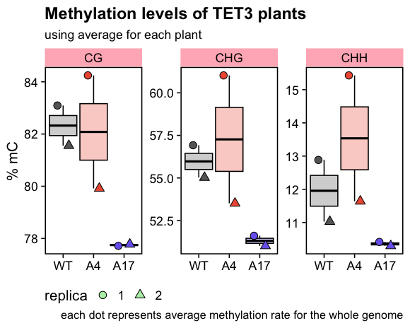

### %mC diff

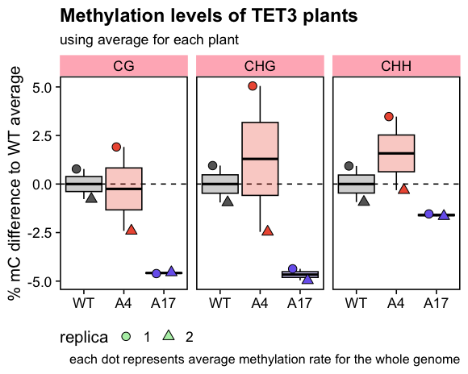

## Distribution of mC levels

Each boxplot represent one replica, with the violin showing the whole set of 100 kb bins

### %mC

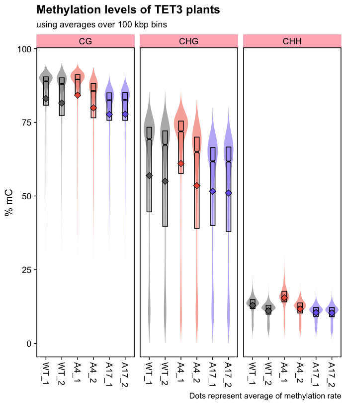

### Difference

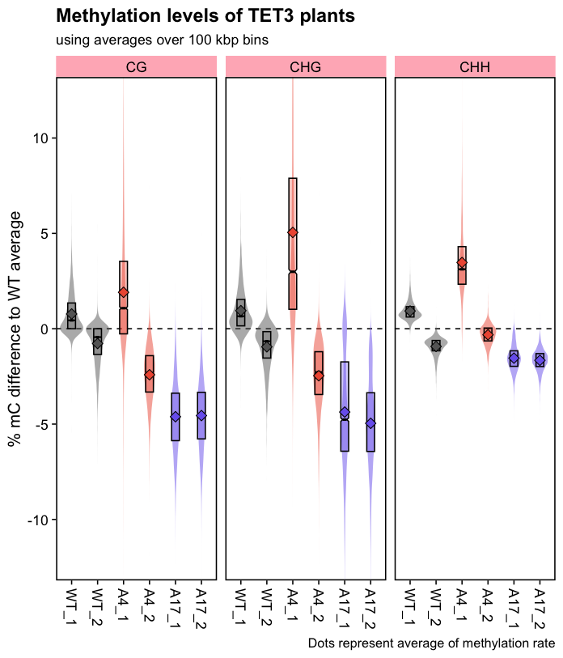

# Merging replicas and removing A4_1

For each bin I computed the difference from each sample to WT.

## Boxplots whole genome

Both A4 (A.T1 TET3) and A17 (A.T1 NT) have lower methylation than WT.

For CG and CHG a big majority of the 100 kbp bins have less methylation in A.T1 TET3 and A.T1 NT than in WT. A.T1 TET3 loses around 2.5% on average while A.T1 NT loses around 5%.

This is interesting because we see the biggest drop in methylation in the genetically WT plant.

For CHG in A.T1 NT we see a bimodal distribution of differences, with one of the peaks being the WT levels. This suggest than some regions lose methylation while others stay as in WT.

in CHH the changes are smaller, and it is not clear if A.T1 TET3 has less methylation than WT, while A.T1 NT has a drop around 2%.

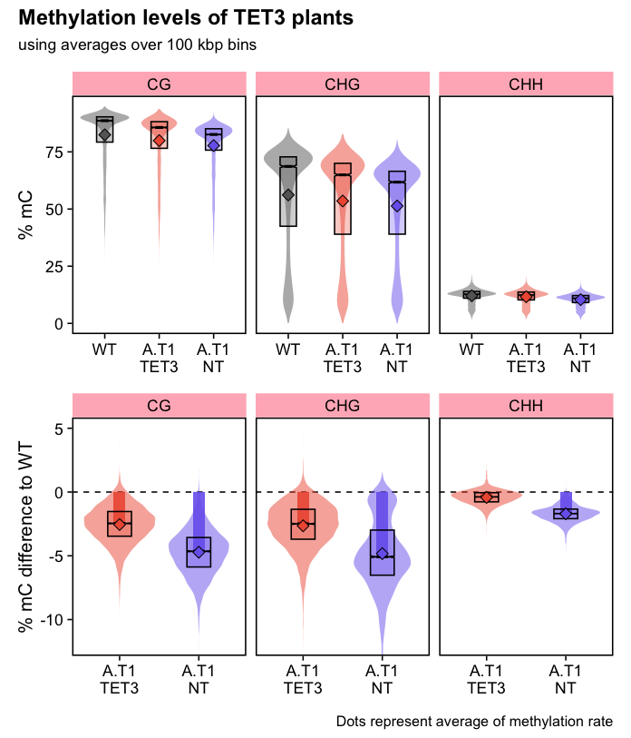

## Split by chromatin state

Using information about location of boundaries between Euchromatin and Heterochromatin inferred from H3K27mac ChIP-seq data, we can compare the changes in DNA methylation between the two compartments of the genome.

We can see the big differences in % mC between the two compartments, which are most striking for CHG context.

For A.T1 TET3 the patterns are similar to what we saw in the low input WGBS: CG demethylation happening in both compartments while CHG mainly in Heterochromatin.

for A.T1 NT we see an even stronger demethylation of the Heterochromatin that extends to CG context, and that explains the bigger global loss compared to A.T1 TET3 and the bimodal distribution for CHG.

For CHH the patterns look similar but much smaller

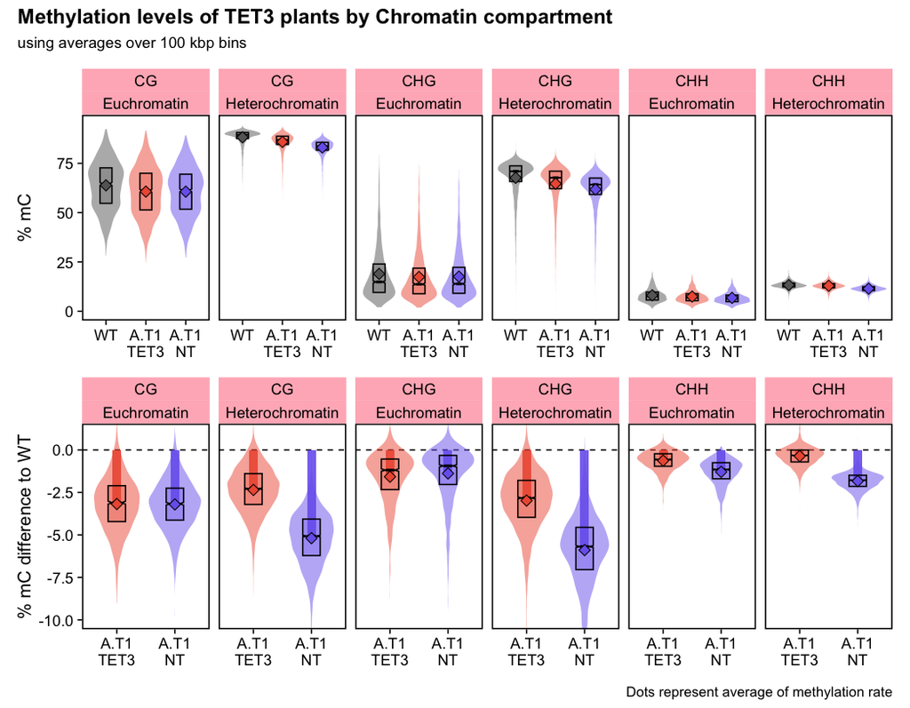